# R - Python Cheat Sheet

Peter McNamara (88451999)

29/09/2019

R and Python are 2 of the most popular languages used for data science currenty. Both mostly have the same functionality but implement it in different ways. This cheat sheet will compare various aspects between the languages, showcasing how to perform the same function in each language.

## Library calls

Both python and R have built-in functions in the base model but to extend functionality, extra packages need to be loaded. Machine learning algorithms, different data structures, better plotting are all available through loading libraries.

For R, the **library** function will allow access to a particular package, whilst in Python, the **import** command is used to import the packages. An alias can be given to this package as generally whenever referencing anything from a package, the package name must be specified. Below, instead of typing `numpy` each time, this is shortened to `np`.

#### R

```r
# Reading files:
library(readr)

# For pipelines:
library(dplyr)
```

#### Python

```python
import numpy as np
import pandas as pd
import os  # for setting the working directory
import matplotlib.pyplot as plt # plotting further down
from math import pi # Import just pi from the math pkg
```

## Data Structures

There are a number of data structures commonly used for storing data for Data Science applications. In R there are:

- vectors, a one-dimensional array of numbers. This can be initialised using **c()**
- matrices, an n-dimensional array of numbers, initialised using the **matrix()** function.
- dataframes which store tables of rows and columns. Each column can be a different type (numeric, character, logical for example).

Python has similar structures:

- lists store collections, which can be any type
- ndarrays are n-dimensional arrays from the **numpy** package
- dataframes again can store a mix of numeric and other data types in a row/column structure. These are initialised from the **pandas** package.

### Manually Creating Matrices and Arrays Structures

#### R

```r
# First create a vector of numbers
vector1 <- c(1, 4, 7, 2, 5, 8, 3, 6, 9)
# Create a 3 x 3 matrix from the vector and
# then specify how many rows and columns there are.
# columns are created first and then rows
m <- matrix(vector1, nrow=3, ncol=3)
print(m)
```

```
##      [,1] [,2] [,3]
## [1,]    1    2    3
## [2,]    4    5    6
## [3,]    7    8    9
```

```r
print(sum(m))
```

```
## [1] 45
```

#### Python

```python
# numpy array can be created from a list of lists.
# Each list is a row in the ndarray
# Result is a 3 x 3 matrix
m = np.array([[1, 2, 3], [4, 5, 6], [7, 8, 9]])
print(m)
```

```
## [[1 2 3]
##  [4 5 6]
##  [7 8 9]]
```

```python
print(np.sum(m)) # Then do a sum over matrix
```

```
## 45
```

### Manually Creating Dataframe Structures

Dataframes are more versatile than matrices or ndarrays as they can store all datatypes, not just numeric. For Python, they can be manually created from dictionaries using the **DataFrame** method. In R, the **data.frame** function concatenates columns together to form the dataframe.

#### R

```r
# Create 3 columns in Dataframe with different types.
# Each column is a vector.
df <- data.frame(colA=c(1, 2, 3),
                 colB=c("First", "Second", "Third"),
                 colC=c(TRUE, FALSE, TRUE))


print(df)
```

```
##   colA   colB  colC
## 1    1  First  TRUE
## 2    2 Second FALSE
## 3    3  Third  TRUE
```

#### Python

```python
# create 3 lists, then put together into a dictionary
# Dictionary then becomes a dataframe.
colA = [1, 2, 3]
colB = ["First", "Second", "Third"]
colC =  [True, False, True]
dict = { 'colA':colA, 'colB':colB, 'colC':colC }
df = pd.DataFrame(dict)
print(df)
```

```
##    colA    colB   colC
## 0     1   First   True
## 1     2  Second  False
## 2     3   Third   True
```

### Adding Rows to Dataframes

Often, a dataframe will need to be expanded to have extra rows added. The new row will have the same columns as the existing dataframe.

R has the **rbind** (row bind) function to add rows whilst Python has the **append** function.

#### R

```r
# Create a new data frame with the same structure
new_row <- data.frame(colA=4,
                 colB="Fourth",
                 colC=FALSE)



# Add the new row to df using rbind
df <- rbind(df, new_row)
```

#### Python

```python
# create a new dictionary, then dataframe
# Then use append method to append row
colA = [4]
colB = 'Fourth'
colC = True
new_dict = { 'colA':colA, 'colB':colB, 'colC':colC }
new_row = pd.DataFrame(new_dict)
# Append the new row to the data frame
df = df.append(new_row, ignore_index=True)
```

### Adding Columns to Dataframes

Dataframes may also have columns added. Here the number of rows stays the same but further columns are added to data structure. This may occur when deriving new fields or creating a dataframe from smaller fragments.

R can be done using:

- **cbind** (column bind)
- using $ notation to add new column

Python does the same either:

- using the **assign** method
- using [] notation

#### R

```r
# Create 2 vectors with the same number of rows
# as the dataframe
new_col1 <- c(0, 5, 10, 15)
new_col2 <- c("A", "B", "C", "D")

# Use cbind to add 1st new column
df <- cbind(df, new_col1)
# Then use $ notation to add the 2nd new column
df$new_col2 <- new_col2

df
```

```
##   colA   colB  colC new_col1 new_col2
## 1    1  First  TRUE        0        A
## 2    2 Second FALSE        5        B
## 3    3  Third  TRUE       10        C
## 4    4 Fourth FALSE       15        D
```

#### Python

```python
# Create 2 new lists
# Same length as dataframe
new_col1 = [0, 5, 10, 15]
new_col2 = ["A", "B", "C", "D"]

# Use assign function to add the column
df = df.assign(new_col1 = new_col1)
# Or use [] notation to create the new column
df["new_col2"] = new_col2

print(df)
```

```
##    colA    colB   colC  new_col1 new_col2
## 0     1   First   True         0        A
## 1     2  Second  False         5        B
## 2     3   Third   True        10        C
## 3     4  Fourth   True        15        D
```

## Reading Files

Datasets are often in files, so a common first step is to read data. Here, the data is in mtcars.csv file and is the mtcars dataset from base R.

In R, the **read.csv** function from the **readr** library is a good option. By default, character strings are converted to factors, so below the code keeps the strings as characters. Also below, the working directory is set and the first column is used as rownames. Also, the separator between columns can be specified. It defaults to a comma (,) if not included.

Python’s **pandas** package has **read_csv** to read a file into a dataframe. Again, the first column can be specified as the rownames. Note that since the import statement set pandas to pd, the read_csv call is `pd.read_csv`. As per R, the separator defaults to a comma but can be specified in the method call.

To display the structure of the resulting dataframes, **str** is used in R and the **info()** method is used in Python.

#### R

```r
# Set the working directory for R
setwd("/GitDev/RPython/data/")

# Read the file to a dataframe
cars = read.csv("mtcars.csv", stringsAsFactors = FALSE,
                row.names = 1, sep=",")
str(cars)   # Show details about dataframe
```

```
## 'data.frame':    32 obs. of  11 variables:
##  $ mpg : num  21 21 22.8 21.4 18.7 18.1 14.3 24.4 22.8 19.2 ...
##  $ cyl : int  6 6 4 6 8 6 8 4 4 6 ...
##  $ disp: num  160 160 108 258 360 ...
##  $ hp  : int  110 110 93 110 175 105 245 62 95 123 ...
##  $ drat: num  3.9 3.9 3.85 3.08 3.15 2.76 3.21 3.69 3.92 3.92 ...
##  $ wt  : num  2.62 2.88 2.32 3.21 3.44 ...
##  $ qsec: num  16.5 17 18.6 19.4 17 ...
##  $ vs  : int  0 0 1 1 0 1 0 1 1 1 ...
##  $ am  : int  1 1 1 0 0 0 0 0 0 0 ...
##  $ gear: int  4 4 4 3 3 3 3 4 4 4 ...
##  $ carb: int  4 4 1 1 2 1 4 2 2 4 ...
```

```r
# Now write the dataframe back out, with rownames
# and a different separator..
write.table(cars, "mtcarsR.csv", row.names = TRUE, sep='|')
```

#### Python

```python
# Set the working directory for Python
os.chdir('c:\\GitDev\\RPython\\data')

# Read the file to a pandas dataframe
cars = pd.read_csv('mtcars.csv',index_col=0)

cars.info()  # Show details about dataframe
```

```
## <class 'pandas.core.frame.DataFrame'>
## Index: 32 entries, Mazda RX4 to Volvo 142E
## Data columns (total 11 columns):
## mpg     32 non-null float64
## cyl     32 non-null int64
## disp    32 non-null float64
## hp      32 non-null int64
## drat    32 non-null float64
## wt      32 non-null float64
## qsec    32 non-null float64
## vs      32 non-null int64
## am      32 non-null int64
## gear    32 non-null int64
## carb    32 non-null int64
## dtypes: float64(5), int64(6)
## memory usage: 3.0+ KB
```

```python
cars.to_csv("mtcarsPy.csv", index=True, sep="|")
# the above writes out the file with rownames and pipe separated
```

## Show dataframe

Both R and Python have **head** and **tail** functions to quickly show a small number of either the first or last rows in a dataframe. Very useful for a quick eyeball of the data. In python this will be a method on dataframe object whereas in R the dataframe object is passed to the function.

**summary** in R shows quartile, min, max and mean information about columns and in Python the **describe** method does similar. These can again be used to quickly understand the data and are shown below.

#### R

```r
# tail(cars, 3) # last 3 rows
head(cars, 3)   # first 3 rows
```

```
##                mpg cyl disp  hp drat    wt  qsec vs am gear carb
## Mazda RX4     21.0   6  160 110 3.90 2.620 16.46  0  1    4    4
## Mazda RX4 Wag 21.0   6  160 110 3.90 2.875 17.02  0  1    4    4
## Datsun 710    22.8   4  108  93 3.85 2.320 18.61  1  1    4    1
```

#### Python

```python
#cars.tail(3)  # last 3 rows
cars.head(3)   # first 3 rows
```

```
##                 mpg  cyl   disp   hp  drat     wt   qsec  vs  am  gear  carb
## Mazda RX4      21.0    6  160.0  110  3.90  2.620  16.46   0   1     4     4
## Mazda RX4 Wag  21.0    6  160.0  110  3.90  2.875  17.02   0   1     4     4
## Datsun 710     22.8    4  108.0   93  3.85  2.320  18.61   1   1     4     1
```

#### R

```r
summary(cars[, 1:2])   # first 2 columns
```

```
##       mpg             cyl
##  Min.   :10.40   Min.   :4.000
##  1st Qu.:15.43   1st Qu.:4.000
##  Median :19.20   Median :6.000
##  Mean   :20.09   Mean   :6.188
##  3rd Qu.:22.80   3rd Qu.:8.000
##  Max.   :33.90   Max.   :8.000
```

#### Python

```python
cars.iloc[:,0:2].describe()   # first 2 columns
```

```
##              mpg        cyl
## count  32.000000  32.000000
## mean   20.090625   6.187500
## std     6.026948   1.785922
## min    10.400000   4.000000
## 25%    15.425000   4.000000
## 50%    19.200000   6.000000
## 75%    22.800000   8.000000
## max    33.900000   8.000000
```

## Aggregating Columns in Dataframe

Often, columns need to be aggregated, to perform data analysis such as Averaging, Summing, etc. With Python, there are methods that are called on an object (everything is an object) whilst for R there are functions to call passing the data required.

Below shows examples of:

- sum
- min
- max
- mean
- median

#### R

```r
cat(paste(sum(cars$mpg),
          min(cars$cyl),
          max(cars$qsec),
          mean(cars$drat),
          median(cars$hp), sep="\n" ) )
```

```
## 642.9
## 4
## 22.9
## 3.5965625
## 123
```

#### Python

```python
print(str(cars["mpg"].sum(axis=0)) + "\n" +
      str(cars["cyl"].min(axis=0))+ "\n" +
      str(cars["qsec"].max(axis=0)) + "\n" +
      str(cars["drat"].mean(axis=0)) + "\n" +
      str(cars["hp"].median(axis=0)))
```

```
## 642.9000000000001
## 4
## 22.9
## 3.5965625
## 123.0
```

## Arithmetic and Logical Operations

The table below compares the different syntax for common operations in R and Python.

| Operation | R | Python |
| --- | --- | --- |
| Addition, Subraction | + - | + - |
| Multiplication, Division | * / | * / |
| modulus | %% | % |
| Integer division | %/% | // |
| Power | ^ | ** |
| OR | \| | or |
| AND | & | and |
| Equal | == | == |
| Not Equal | != | != |
| Greater Than | > | > |
| Less Than | < | < |
| Greater than or Equal to | >= | >= |
| Less Than or Equal to | <= | <= |

## Code Blocks

Python relies on indentation to denote code blocks whilst R uses pairs of braces {}. Indenting does not affect R but just makes the code more readable. Examples of code blocks will be in the sections below.

### Loops and If Statements

Both languages provide `For` and `While` loops for iterating. This can be important for processing each row of a file or dataframe, performing tailored operations on each row.

R uses **If, else if, .., else** for having more than one option in a if else structure whilst Python has **if, elif, .., else** to perform the same flow.

As mentioned in the code blocks section, loops and if statements in R use braces to encompass the steps at each level whilst Python uses : and indentation. For formatting, to go over multiple lines with the same statement in Python (for example an if statement with multiple conditions, either ‘\’ can be put at the end of the line to split onto the next line or the statement can be enclosed in parentheses.

R must have loop control and conditions within parentheses (). R additionally requires the closing brace and **else** or **else if** to be on the same line.

#### R

```r
count_low = 0
count_mid = 0
count_high = 0

for (i in 1:nrow(cars)) {
  if (cars[i, ]$mpg %/% 5 <= 2) {
    count_low = count_low + 1
  # closing brace and else if are on same line
  } else if (cars[i, ]$mpg %/% 5 > 2 &
             cars[i, ]$mpg %/% 5 <= 3) {
      count_mid = count_mid + 1
   } else {
      count_high = count_high + 1
   }
}
# To concatenate, paste() is used which defaults to
# one space between each element
print(paste("Low/Medium/High =", count_low, count_mid, count_high))
```

```
## [1] "Low/Medium/High = 5 13 14"
```

#### Python

```python
count_low = 0
count_mid = 0
count_high = 0

for i, row in cars.iterrows():
   if row["mpg"] // 5 <= 2:
      count_low = count_low + 1
   # condition goes over multiple lines using \
   elif row["mpg"] // 5 > 2 and \
        row["mpg"] // 5 <= 3:
      count_mid = count_mid + 1
   else:
      count_high = count_high + 1


# Note that integers MUST be converted to strings
# for display and extra spaces added explicitly
print("Low/Medium/High = " + str(count_low) + " " + str(count_mid) + " " + str(count_high))
```

```
## Low/Medium/High = 5 13 14
```

### Functions

Functions are a good way of reusing code, where the same code is re-run multiple times from different sections. R and Python both allow for user-defined functions.

In R, a variable is assigned as a **function()** and again the code for the function is enclosed in braces as it is a code block. Parameters are specified within the function parentheses and can be have a default value for when they are not passed. To return an object from the function, either reference it on the final line of the function or explicitly use **return**.

Python uses the **def** call to define a function and as consistent with Python, : and indentation are used to define the code within the function. As with R, parameters can be passed and defaulted when not passed. Passing back from a function uses the **return** statement.

#### R

```r
sum_rows <- function (df, p_double=FALSE) {

  i = 1
  sum_row = 0
  while (i <= nrow(df)) {
    sum_row = sum_row + sum(df[i, ])

    i = i + 1
  }

  if (p_double) {
    sum_row = sum_row * 2
  }
  # return is optional, just reference the variable
  sum_row

}

cat(paste("total sums =", sum_rows(cars),
          sum_rows(cars, TRUE),
          sum_rows(p_double=TRUE, df=cars), sep="\n"))
```

```
## total sums =
## 13942.202
## 27884.404
## 27884.404
```

#### Python

```python
def sum_rows(df, p_double=False):

   i = 0
   sum_row = 0
   while i < len(df):
      sum_row = sum_row + df.iloc[i].sum()

      i = i + 1


   if p_double:
      sum_row = sum_row * 2

   # Return the value
   return sum_row



print("total sums =\n" + str(sum_rows(cars)) + "\n" +        str(sum_rows(cars, True)) + "\n" +
      str(sum_rows(p_double=True, df=cars)))
```

```
## total sums =
## 13942.202000000001
## 27884.404000000002
## 27884.404000000002
```

## Filtering Dataframes

Under R, there are many ways to filter rows and columns from a dataframe:

- Base R provides square bracket notation [] to filter rows and columns
- The `dplyr` package simplifies many functions into a pipeline where **%>%** passes the previous manipulation into the next function. Here, **filter** can be used to filter rows and then **select** can be used to limit the number of columns.

Python also provides a number of different ways to select rows and columns:

- using square bracket [] notation
- using loc and iloc methods

Python uses zero-based indexing so that the first element in a list, array etc., is at index 0, the second at index 1 and so on.

#### R

```r
# using [ , ], the first part are the rows to select
# and after the comma are the columns to return
# Select columns by name
df1 <- cars[, c("mpg", "cyl") ]




# Select the 1st 4 rows
df2 <- cars[1:4, ]
# Select rows and columns by name
df3 <- cars[c("Mazda RX4", "Datsun 710"),
            c("mpg", "cyl")]

# use select to get columns
df4 <- cars %>% select(cyl, mpg)

# Selecting 1 column returns a vector
# Wrapping in as.data.frame will return a dataframe
vector1 <- cars[, c("cyl")]

# Select rows and columns by position
df5 <- cars[c(1:3), c(9:11)]
# Select rows and columns by number
df6 <- cars[c(1, 3, 5), c(4, 6, 8)]

# Using dplyr structure, filter on rows and
# then select columns
df7 <- cars %>%
  filter(cyl==4) %>%
  select(mpg, cyl, qsec)

cat(paste(paste(nrow(df1), ncol(df1), sep = ", "),
          paste(nrow(df2), ncol(df2), sep = ", "),
          paste(nrow(df3), ncol(df3), sep = ", "),
          paste(nrow(df4), ncol(df4), sep = ", "),
          paste(nrow(df5), ncol(df5), sep = ", "),
          paste(nrow(df6), ncol(df6), sep = ", "),
          paste(nrow(df7), ncol(df7), sep = ", "),
          length(vector1), sep="\n"))
```

```
## 32, 2
## 4, 11
## 2, 2
## 32, 2
## 3, 3
## 3, 3
## 11, 3
## 32
```

#### Python

```python
# Selecting columns with [], columns can be names
df1 = cars[["mpg", "qsec"]]
# Select rows with a slice.  Rows start from 0.
# When specifying a range, the 1st number is the
# row number (starting at 0) and the second is
# one past the row being returned so
# here we select rows 0, 1, 2 and 3 but not 4
df2 = cars[0:4]
# loc method uses the row and column names
df3 = cars.loc[["Mazda RX4", "Datsun 710"],
               ['cyl', 'drat']]

# : by itself below means the slice is all rows
df4 = cars.loc[:, ['cyl', 'mpg']]
# Single brackets on one column will return a
# pandas series, not a dataframe.
# Double brackets return a 1-column dataframe
series1 = cars["cyl"]

# iloc method uses indexes rather than names
df5 = cars.iloc[0:3, 8:11]
# Pick different rows and columns
df6 = cars.iloc[[0, 2, 4], [5, 7, 9]]

# Use condition to filter rows and then select columns
# Since columns are named, loc is used
df7 = cars.loc[cars["cyl"] == 4,
               ["mpg", "cyl", "qsec"]]


print(str(df1.shape) + "\n"
    + str(df2.shape) + "\n"
    + str(df3.shape) + "\n"
    + str(df4.shape) + "\n"
    + str(df5.shape) + "\n"
    + str(df6.shape) + "\n"
    + str(df7.shape) + "\n"
    + str(series1.shape))
```

```
## (32, 2)
## (4, 11)
## (2, 2)
## (32, 2)
## (3, 3)
## (3, 3)
## (11, 3)
## (32,)
```

## Basic Plots

R has basic plotting built in to the language whereas for Python, the **matplotlib** library is a good starting point to do quick plotting. Visualisation is a great way to explore data and relationships which is a key function of data science.

Note that in Python, to display the graph, the **show()** method is used. To then show another plot, the graph must be cleared first with **clf()**

Below first builds a scatterplot and then a histogram.

#### R

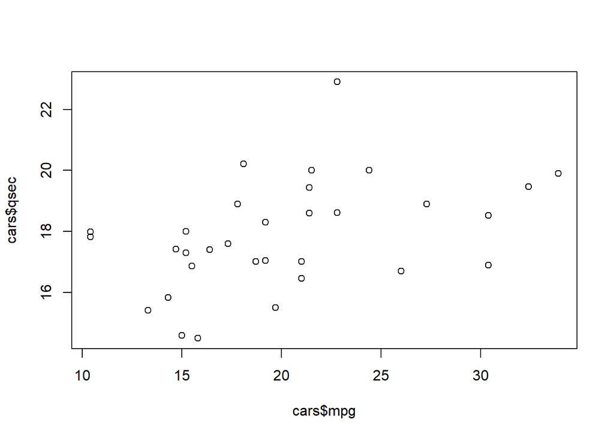

```r
# to plot a scatterplot, plot can be used
#
#
plot(cars$mpg, cars$qsec)
```

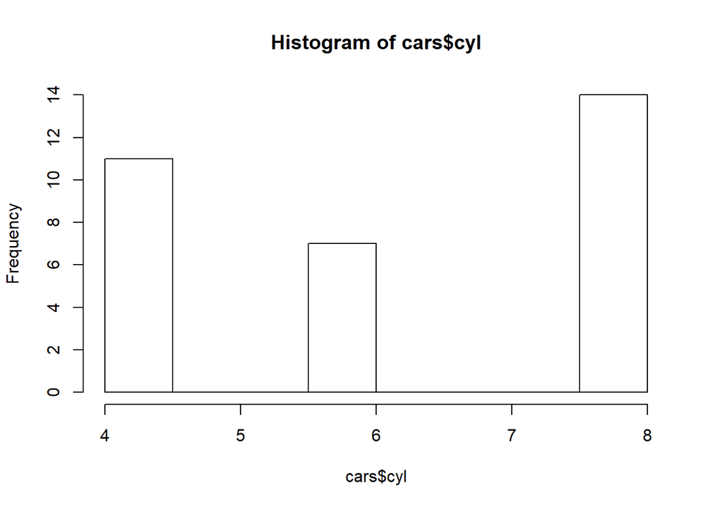

```r
#
# hist is used to print a histogram
hist(cars$cyl)
```

#### Python

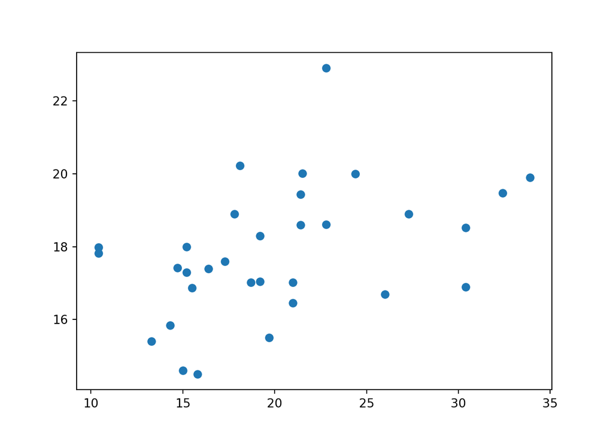

```python
# make a scatter plot with the plt object
plt.scatter(cars["mpg"], cars["qsec"])
# Display the plot with plt.show()
plt.show()
```

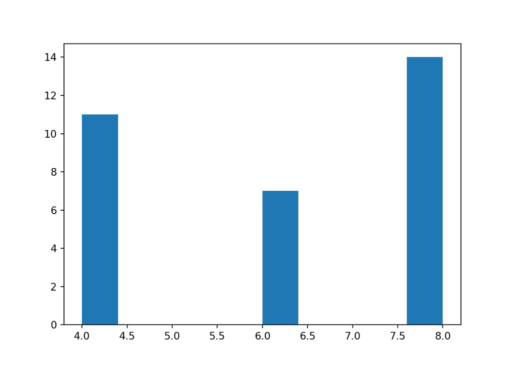

```python
plt.clf()  # Clear the figure
counts, bins, bars = plt.hist(cars["cyl"])
plt.show() # then show the new graph
```